# PracticalMachineLearning_Project

SreeramMakam

February 28, 2016

# 1. About this project

In this project we study the collected data from accelerometers on the belt, forearm, arm, and dumbell from 6 participants who did some exercises and their data is saved in raw format in two sets as Training and Test sets as given by the URL’s.

# 2. Task

In this exercise, we will come up with a model to predict the outcome(CLASSE variable) which is one of the 5 ways the participants did their exercise using the Train and Test data and cross validate and also calculate the expected out of sample error along with the choices made.

```r
#Loading Caret, RandomForest, ggplot2, lattice and rpart.plot library used.
library(caret)
library(randomForest)
library(ggplot2)
library(lattice)
library(rpart.plot)
set.seed(12345)

#Clearing Workspace
rm(list=ls())
setwd("C:/Users/makam/Desktop/Coursera/PracticalMachineLearning/Project")

# Download data.
url_raw_training <- "https://d396qusza40orc.cloudfront.net/predmachlearn/pml-training.csv"
file_dest_training <- "pml-training.csv"
download.file(url=url_raw_training, destfile=file_dest_training)
url_raw_testing <- "https://d396qusza40orc.cloudfront.net/predmachlearn/pml-testing.csv"
file_dest_testing <- "pml-testing.csv"
download.file(url=url_raw_testing, destfile=file_dest_testing)
```

# 3.Exploratory Data Analysis

## Converting the miscellaneous NA, #DIV/0! and empty fields as NA.

```r
# Load the training data set
trainingData<- read.csv("pml-training.csv", na.strings = c("NA", "#DIV/0!", ""))
```

## Exploring and Mashing the data.

```r
# Number of columns
ncol(trainingData)
```

```
## [1] 160
```

```r
# Number of rows
nrow(trainingData)
```

```
## [1] 19622
```

```r
# Summary
summary(trainingData[,c(1:2,159:160)])
```

```
##        X            user_name    magnet_forearm_z classe
##  Min.   :    1   adelmo  :3892   Min.   :-973.0   A:5580
##  1st Qu.: 4906   carlitos:3112   1st Qu.: 191.0   B:3797
##  Median : 9812   charles :3536   Median : 511.0   C:3422
##  Mean   : 9812   eurico  :3070   Mean   : 393.6   D:3216
##  3rd Qu.:14717   jeremy  :3402   3rd Qu.: 653.0   E:3607
##  Max.   :19622   pedro   :2610   Max.   :1090.0
```

```r
str(trainingData, list.len=15)
```

```
## 'data.frame':    19622 obs. of  160 variables:
##  $ X                       : int  1 2 3 4 5 6 7 8 9 10 ...
##  $ user_name               : Factor w/ 6 levels "adelmo","carlitos",..: 2 2 2 2 2 2 2 2 2 2 ...
##  $ raw_timestamp_part_1    : int  1323084231 1323084231 1323084231 1323084232 1323084232 1323084232 1323084232 1323084232 1323084232 1323084232 ...
##  $ raw_timestamp_part_2    : int  788290 808298 820366 120339 196328 304277 368296 440390 484323 484434 ...
##  $ cvtd_timestamp          : Factor w/ 20 levels "02/12/2011 13:32",..: 9 9 9 9 9 9 9 9 9 9 ...
##  $ new_window              : Factor w/ 2 levels "no","yes": 1 1 1 1 1 1 1 1 1 1 ...
##  $ num_window              : int  11 11 11 12 12 12 12 12 12 12 ...
##  $ roll_belt               : num  1.41 1.41 1.42 1.48 1.48 1.45 1.42 1.42 1.43 1.45 ...
##  $ pitch_belt              : num  8.07 8.07 8.07 8.05 8.07 8.06 8.09 8.13 8.16 8.17 ...
##  $ yaw_belt                : num  -94.4 -94.4 -94.4 -94.4 -94.4 -94.4 -94.4 -94.4 -94.4 -94.4 ...
##  $ total_accel_belt        : int  3 3 3 3 3 3 3 3 3 3 ...
##  $ kurtosis_roll_belt      : num  NA NA NA NA NA NA NA NA NA NA ...
##  $ kurtosis_picth_belt     : num  NA NA NA NA NA NA NA NA NA NA ...
##  $ kurtosis_yaw_belt       : logi  NA NA NA NA NA NA ...
##  $ skewness_roll_belt      : num  NA NA NA NA NA NA NA NA NA NA ...
##   [list output truncated]
```

```r
table(trainingData$classe)
```

```
##
##    A    B    C    D    E
## 5580 3797 3422 3216 3607
```

Clean-up by removing columns 1 to 6, which are there just for information and reference purposes

```r
trainingData <- trainingData[, 7:160]
```

After a visual check of the data , there were lots of missing data (NA), therefore only the columns with more then 5 pct of data have been retained. Reason , when there is less then 5 pct data, the chance that they influence the result is small and is just computerresuorces consuming. Discard columns with at least 95 pct missing data

```r
# Discard columns with at least 95 pct NAs
NAs <- apply(trainingData, 2, function(x) { sum(is.na(x)) })
trainingData <- trainingData[, which(NAs < nrow(trainingData)*.95)]
ncol(trainingData)
```

```
## [1] 54
```

Split of the training set into two for cross validation purposes.Randomly subsample 60% of the set for training purposes, while the 40% remainder will be used only for testing, evaluation and accuracy measurement.

```r
inTrain <- createDataPartition(y=trainingData$classe, p=0.60, list=FALSE)
train1  <- trainingData[inTrain,]
train2  <- trainingData[-inTrain,]
dim(train1)
```

```
## [1] 11776    54
```

```r
dim(train2)
```

```
## [1] 7846   54
```

Identify the “zero covariates”" from train1 and [ii] remove these “zero covariates”" from both train1 and train2

```r
nzv_cols <- nearZeroVar(train1)
if(length(nzv_cols) > 0) {
  train1 <- train1[, -nzv_cols]
  train2 <- train2[, -nzv_cols]
}
dim(train1)
```

```
## [1] 11776    54
```

```r
dim(train2)
```

```
## [1] 7846   54
```

This step didn’t do anything as the earlier removal of NA was sufficient to clean the data.

# Data Preparation

Random Forest will be used to train the Prediction Model set to predict the weight lifting quality in the Training Set.

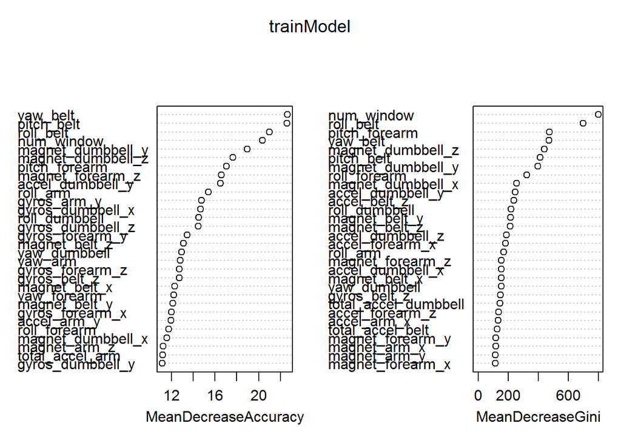

```r
trainModel <- randomForest(classe~., data=train1, importance=TRUE, ntree=100)
varImpPlot(trainModel)
```

Our 10 covariates are: yaw_belt, roll_belt, num_window, pitch_belt, magnet_dumbbell_y, magnet_dumbbell_z, pitch_forearm, accel_dumbbell_y, roll_arm, and roll_forearm.

Let’s analyze the correlations between these 10 variables. The following code calculates the correlation matrix, replaces the 1s in the diagonal with 0s, and outputs which variables have an absolute value correlation above 75%:

```r
correl = cor(train1[,c("yaw_belt","roll_belt","num_window","pitch_belt","magnet_dumbbell_z","magnet_dumbbell_y","pitch_forearm","accel_dumbbell_y","roll_arm","roll_forearm")])
diag(correl) <- 0
which(abs(correl)>0.75, arr.ind=TRUE)
```

```
##           row col
## roll_belt   2   1
## yaw_belt    1   2
```

So we may have a problem with roll_belt and yaw_belt which have a high correlation (above 75%, actually 81%) with each other:

```r
cor(train1$roll_belt, train1$yaw_belt)
```

```
## [1] 0.814133
```

These two variables are on top of the Accuracy and Gini graphs, and it may seem scary to eliminate one of them. Let’s be bold and without doing any PCA analysis, we eliminate yaw_belt from the list of 10 variables and concentrate only on the remaining 9 variables.

By re-running the correlation script above (eliminating yaw_belt) and outputting max(correl), we find that the maximum correlation among these 9 variables is 50.57% so we are satisfied with this choice of relatively independent set of covariates.

```r
correl = cor(train1[,c("roll_belt","num_window","pitch_belt","magnet_dumbbell_z","magnet_dumbbell_y","pitch_forearm","accel_dumbbell_y","roll_arm","roll_forearm")])
diag(correl) <- 0
which(abs(correl)>0.75, arr.ind=TRUE)
```

```
##      row col
```

We can identify an interesting relationship between roll_belt and magnet_dumbbell_y:

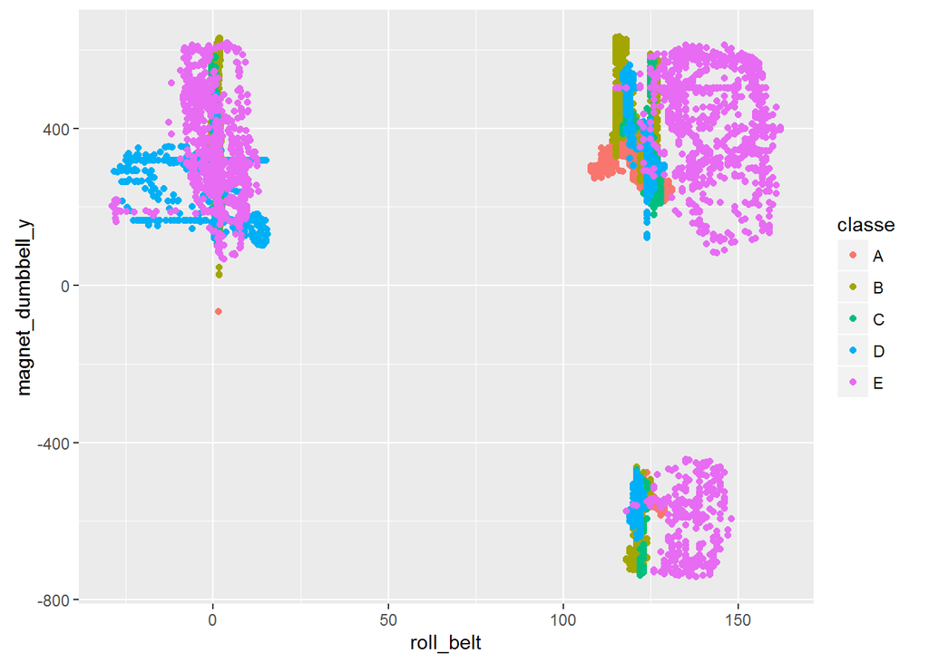

```r
qplot(roll_belt, magnet_dumbbell_y, colour=classe, data=train1)
```

This graph suggests that we could probably categorize the data into groups based on roll_belt values.

Incidentally, a quick tree classifier selects roll_belt as the first discriminant among all 53 covariates (which explains why we have eliminated yaw_belt instead of roll_belt, and not the opposite: it is a “more important” covariate):

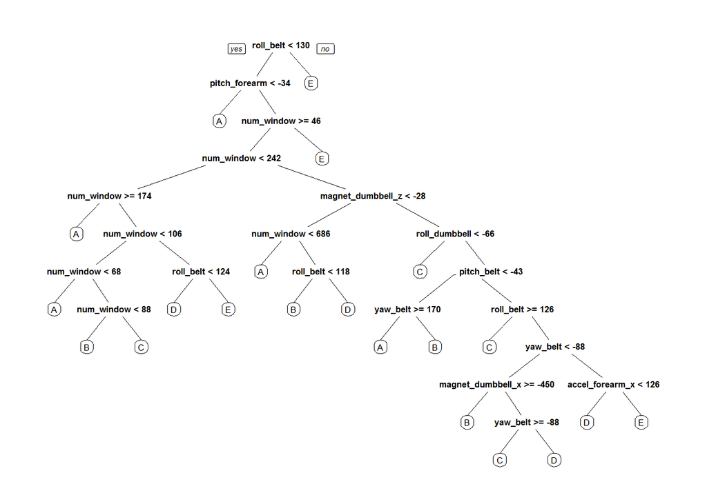

```r
fitModel <- rpart(classe~., data=train1, method="class")
prp(fitModel)
```

```r
fitModel <- train(classe~roll_belt+num_window+pitch_belt+magnet_dumbbell_y+magnet_dumbbell_z+pitch_forearm+accel_dumbbell_y+roll_arm+roll_forearm,
                  data=train1,
                  method="rf",
                  trControl=trainControl(method="cv",number=2),
                  prox=TRUE,
                  verbose=TRUE,
                  allowParallel=TRUE)
```